# Spatial Extremes

Seoncheol Park

12/12/2019

- 메모: Ribatet의 발표자료 “Max-stable processes: Theory and Inference”에서 나오는 unit Frechet margin을 쓰는 이유로
  $$P[Z(x_1)\leq z_1 ,\ldots, Z(x_k)\leq x_k]=\exp\{ -V(z_1, \ldots, z_k) \}$$
  exponent function $V$가 some homogeneity properties depending on the margins를 갖는데 우리가 unit Frechet margins를 가정하면 $V$는 homogenous of order $-1$이 되어
  $$-\log (P[Z(x_1)\leq z_1 ,\ldots, Z(x_k)\leq x_k]) = V(z, \ldots, z) \stackrel{hom.}{=}\frac{\theta_{k}}{z}$$
  이 되어 이 때 $\theta_{k}=V(1,\ldots, 1)$이 **extremal coefficient**가 된다.

# 1 공간 극단값 이론과 최대안정과정

이 절은 **최대안정과정(max-stable process)** 및 이것의 **공간 극단값(spatial extremes)**이론으로의 응용에 초점을 맞춰 서술한다. 이 절의 서술 내용은 Coles (2011) 과 Dey and Yan (2015) 를 참고하였다. 그림은 R 패키지 `SpatialExtremes`를 이용하였다. 더불어 Alan Gelfand (2019) 의 서술도 참고한다.

## 1.1 최대안정과정에서의 포아송과정(Poisson process in Max-stable process)

여기의 내용은 Alan Gelfand (2019) 의 31.2를 참고하였다. **포아송과정(Poisson process)**는 state space $\mathcal{E}$에 놓여 있는 ramdom point들의 집합 $\mathcal{P}$에 대한 확률모형으로 확률변수들의 두 가지 성질들에 의해 정의된다.
$$N(\mathcal{A})=|\{x: x\in \mathcal{P}\cap \mathcal{A}\}|, \mathcal{A}\subset \mathcal{E}$$
는 집합 $\mathcal{A}$안에 $\mathcal{P}$의 점들이 얼마나 많이 들어있는지 세는 역할을 한다. 이 때 $\mathcal{A}$는 $\mathcal{E}$의 any collection of disjoint subsets로 $A_1,\ldots, A_n \subset \mathcal{E}$이다. $N(\mathcal{A}_1), \ldots, N(\mathcal{A}_n)$은 독립이다. $N(\mathcal{A})$는 평균이 $\mu(\mathcal{A})$인 포아송 분포를 따른다. 이 때 $\mu$를 그 과정의 **평균측도(mean measure)**라고 부른다. 또한 평균측도는 non-atomic, 즉 $\mu(\{x\})=0$ for any singleton $x\in\mathcal{E}$이어야 한다. 더불어 $\mu(\emptyset)=0$이지만 $\mu(\mathcal{E})$는 무한대가 될 수도 있다. ($N(\mathcal{E})$가 확률 1로 무한대인 경우) 여기서는 기술적인 이유들로 $\mu(\mathcal{A})<\infty$인 $\mathcal{A}$에만 관심을 갖도록 한다.

Consider, for example, a Poisson process with $\mathcal{E}=\mathbb{R}_{+}^{2}$, that generates points $x=(r,w)$ according to the mean measure

$$\begin{equation}
\mu\{(r,\infty)\times (w,\infty)\}=\frac{1}{r}\times \Phi(-\frac{1}{\sigma}\log w - \frac{\sigma}{2}), \qquad{r,w>0}
\end{equation}$$

where $\sigma>0$ and $\Phi$ is the standard normal distribution function.

This corresponds to setting $\mathcal{P}=\{ (R_i, W_i): i=1,2,\ldots \}$, where $E_i \stackrel{\text{iid}}{\sim}\text{exp}(1)$, and $W_i = \text{exp}(\sigma \varepsilon_i - \frac{\sigma^2}{2})$, where $\varepsilon\stackrel{\text{iid}}{\sim} \mathcal{N}(0,1)$, indpendnet of the $E_{i}$. Note that $E(W_i)=1$.

The mean measure has an **intensity function** $\dot{\mu}$ given by its derivative at the upper right corner of a rectangle $(r', r)\times (w', w)$, i.e.,

$$\begin{align}
\dot{\mu}(r,w) &= \frac{\partial^2 \mu \{ (r',r)\times (w',w) \}}{\partial r \partial w}\nonumber\\
&= \frac{\partial^2}{\partial r \partial w}\{ \mu(r',w')-\mu(r,w')-\mu(r',w)+\mu(r,w) \}\\
&= \frac{1}{r^2}\times \frac{1}{\sigma w}\phi(-\frac{1}{\sigma}\log w -\frac{\sigma}{2}), \qquad{r, w >0,}
\end{align}$$

where we have written $\mu(r,w)=\mu\{ (r,\infty)\times (w,\infty) \}$ and so forth, and $\phi$ denotes the standard normal density function. Note that $\mu(\mathcal{A})$ equals the integral of $\dot{\mu}$ over $\mathcal{A}$.

A key role in constructing models for spatial extremes is played by the **mapping theorem**.

**Theorem 1.1 (mapping theorem)** Under mild conditions states that if a function $g$ does not create atoms, then $\mathcal{P}^{*}=g(\mathcal{P})$ also follows a Poisson process.

As a simple example we might take $g(r,w)=rw$, corresponding to setting $Q_i = R_i W_i$. Clearly $\mu[ \{ (r,\frac{q}{r}): r>0 \} ]=0$ for each $q>0$, so this transformation does not create atoms. We obtain the mean measure of this new Poisson process by noting that $Q=RW>q$ if and only if $R>\frac{q}{W}$, and the corresponding set $\mathcal{A}_{q}=\{(r,w):rw>q\}$ has measure

$$\begin{align}
\mu(\mathcal{A}_q) &= \int_{0}^{\infty} \frac{1}{\sigma w}\phi(-\frac{1}{\sigma}\log w -\frac{\sigma}{2})\int_{r=\frac{q}{w}}^{\infty}\frac{1}{r^2}drdw\nonumber\\
&=\int_{0}^{\infty} \frac{1}{\sigma w}\phi(-\frac{1}{\sigma}\log w -\frac{\sigma}{2})\Big[ -\frac{1}{r} \Big]_{\frac{q}{w}}^{\infty}dw\nonumber\\
&= \frac{1}{q}E(W)=\frac{1}{q}, \qquad{q>0}.
\tag{1.1}
\end{align}$$

Hence the process with points $Q_i = R_iW_i$ is also Poissonian, with the same mean measure as the $R_i$. Note that the calculation leading to (1.1) requires only that $W$ is positive and satisfies $E(W)=1$.

The restriction of $\mathcal{P}$ to a subset $\mathcal{E}'$ $\mathcal{E}$ clearly also follows a Poisson process, with mean measure $\mu'(\mathcal{A})=\mu(\mathcal{E}'\cap \mathcal{A})$. For example, if we let $\mathcal{E}=(0,\infty)$, consider $R_1, R_2, \ldots,$ and let $\mathcal{E}'=(z',\infty)$ for some $z'>0$, then we retain only those poins $R_i$, exceeding $z'$. As $\mu(\mathcal{E}')=\frac{1}{z'}$ is finite, those $R_i$ can be generated by first simulating a Poisson variable $N'$ with mean $\frac{1}{z'}$, and if $N'=n$, simulating $n$ independent variables on the interval $(z',\infty)$ with survivor function $\frac{z'}{z}$; these Pareto variables have probability density function $\frac{z'}{z^2}$ ($z>z'$).

## 1.2 Classical results

To connect the above rather abstract discussion with classical results for maxima of a random sample $X_1, \ldots, X_n$, note for any real $b_n$ and positive $a_n$ that

$$\begin{equation}
\frac{\max (X_1, \ldots, X_n)-b_n}{a_n}\leq y \Leftrightarrow N_n\{ (y,\infty) \}=0,
\tag{1.2}
\end{equation}$$

where $N_n(\mathcal{A})=\sum_{j=1}^{n}I\{\frac{(X_j-b_n)}{a_n}\in\mathcal{A}\}$ for $\mathcal{A}\subset \mathbb{R}$; $N_n(\mathcal{A})$ has a binomial distribution. If the extremal types theorem applies to $X_1, \ldots, X_n$, then there exist sequences $\{b_n\}$ and $\{a_n\}>0$ such that limiting probability of (1.2) is a generalized extreme value (GEV) form, and this implies that the binomial random variables $N_n\{(y,\infty\}$ satisfy

$$\begin{equation}
\lim_{n\rightarrow\infty}P[N_n \{ (y,\infty\}=0]=\exp\Bigg\{ - \Big( 1 + \xi \frac{y-\eta}{\tau} \Big)_{+}^{-\frac{1}{\xi}} \Bigg\},
\tag{1.3}
\end{equation}$$

where $a_+ = \max(a,0)$ and $\xi,\eta\in\mathbb{R}$ and $\tau > 0$ are respectively shape, location and scale parameters. Thus as $n\rightarrow\infty$, the point processes $\mathcal{P}_n = \{\frac{(X_n-b_n)}{a_n}: j=1,\ldots, n \}$ converge to a limiting Poisson process $\mathcal{P}$ with mean measure $\mu\{(y,\infty) \}=\{1+ \xi\frac{y-\eta}{\tau} \}_{+}^{-\frac{1}{\xi}}$. The limiting generalized extreme-value distribution for the maximum corresponds to the probability that the set $(y,\infty)\cap \mathcal{P}$ contains no points, a void probability of $\mathcal{P}$. This distribution arises as a limit, and thus provides an approximation that should improve as $n$ increases. Likewise the Poisson process approximately may be poor unless $n$ is sufficiently large.

The process $\mathcal{P}$ can be transformed to have mean measure $\frac{1}{z}$ on $\mathbb{R}_{+}$ by setting $z=\{1+ \xi\frac{y-\eta}{\tau} \}_{+}^{-\frac{1}{\xi}}$, and fitting (1.3) to sample maxima can be regarded as finding the $\eta, \tau$, and $\xi$ that best achieve this. On this transformed scale the maximum has limiting distribution function $\exp(-\frac{1}{z})$ $(z>0)$; this, the stnadrad Frechet distribution, corresponds to (1.3) with $\eta=\tau=\xi=1$.

The **generalized extreme-value distribution** is **max-stable**; in the case of independent standard Frechet variables $Z, Z_1, \ldots, Z_n$, this means that

$$\begin{equation}
\frac{1}{n}\max(Z_1,\ldots, Z_n)\stackrel{D}{=}Z, \qquad{n=1,2,\ldots}
\tag{1.4}
\end{equation}$$

where $\stackrel{D}{=}$ means ‘has the same distribution as’; these equalities correspond to setting $b_n=0$ and $a_n=n$ in (1.2).

The **generalized Pareto distribution** (GPD) emerges on noting that large values of the transformed original variables $Z_j = \{ 1+ \xi \frac{(X_j - \eta)}{\tau} \}_{+}^{\frac{1}{\xi}}$ approximately follow a Poisson process on $\mathbb{R}_{+}$ with the mean measure $\frac{1}{z}$. Those points for which $X_j > u$, or equivalently $Z_j > \{ 1+\xi\frac{(u-\eta)}{\tau} \}_{+}^{\frac{1}{\xi}}$, for some high threshold $u$, satisfy

$$\begin{align}
P(X_j>y | X_j > u) &= \frac{P(X_j >y)}{P(X_j>u)}\nonumber\\
&\stackrel{\cdot}{=} \frac{\{ 1+\xi \frac{(y-\eta)}{\tau} \}_{+}^{-\frac{1}{\xi}}}{\{1+\xi \frac{(u-\eta)}{\tau} \}_{+}^{-\frac{1}{\xi}}}\nonumber\\
&= \Big( 1+ \xi \frac{y-u}{\sigma_u} \Big)_{+}^{-\frac{1}{\xi}}, \qquad{y>u},\nonumber
\end{align}$$

where $\sigma_{u} = \tau + \xi(u-\eta)$; this yields the generalized Pareto distribution, which is therefore the limiting model for threshold exceedances that corresponds to fitting (1.3) to maxima. This ditribution is **threshold-stable**: it is easy to check that the distribution of each $X_j$, conditional on the event $X_j > u'>u$, is also generalized Pareto, with the same shape parameter $\xi$. Like the GEV and Poisson process, the GPD approximation stems from a limit and may be poor if the threshold $u$ is too low.

## 1.3 Spectral representation

Spectral representation은 Laurens de Haan (2006) 의 Theorem 9.6.1에도 소개되어있다. Morris, Reich, and Thibaud (2019) 의 해석에 따르면 어떤 max-stable process가 countable number of spatial process로 표현될 수 있다는 것이다. 이 process에는 Gaussian process ((Schlather 2002)), log-Gaussian process ((Kabluchko, Schlather, and Haan 2009)) 등이 있다.

The Poisson process allows a general discussion of the classical extreme-value models in terms of a **spectral representation**, to be described below. This applies to the univariate setting, the multivariate setting, and to the functional setting, which we now describe.

**Max-stability** is the key property of the generalized extreme-value distribution that underpins (버팀목을 대다) its use for the estimation of rare event probabilities. On the standard Frechet scale this may be expressed to (1.4), and the analogous equation for max-stable process, which generalize the GEV to multivariate and functional settings, is

$$\begin{equation}
\frac{1}{n}\max(Z_1(x),\ldots, Z_n(x))\stackrel{D}{=}Z(x), \qquad{x\in\mathcal{X},n=1,2,\ldots ;}
\tag{1.5}
\end{equation}$$

we require (1.5) to hold for the entire process $\{Z(x): x\in\mathcal{X}\}$. When $\mathcal{X}$ is a finite set, this corresponds to the max-stability of the multivariate extreme-value distributions.

To generalize our previous discussion, we extend the Poisson process $(R,W)$ so that $\{W(x): x\in\mathcal{X}\}$ is a random process taking values in a suitable space of functions, with $W(x)\geq 0$ and $E\{W(x)\}=1$ for each $x$. The topology on the function space, and the distribution of $W$, must be sufficiently rich that the measure of $(R,W)$ remains non-atomic. Despite this added complexity, we continue to use the term points for $(R,W)$ and $Q(x)=RW(x)$.

Any max-stable process may then be constructed through the **spectral representation**,

$$\begin{equation}
Z(x)=\sup_{i=1}^{\infty}Q_{i}(x), \qquad{x\in\mathcal{X},}
\tag{1.6}
\end{equation}$$

where $Q_i(x)=R_iW_i(x)$, with the $R_i$ defined as before and the $W_i(x)$ independent replicates of $W(x)$ independent of the $R_i$. Then the point $Q_i(x)$ may be interpreted as the $i$-th event, whose overall ‘scale’ and profile are respectively $R_i$ and $W_i(x)$.

Since $W(x)\geq 0$ and $E\{W(x)\}=1$ for each $x$, the mean measure for $Q(x)=RW(x)$ is (1.1), so $P\{Z(x) \leq z\}=\exp(-\frac{1}{z})$ for each $x$; the max-stable process is then called **simple**.

It may be shown that any max-stable process may be constructed via (1.6), though the representation is not unique. Recal that in deriving (1.1), we saw that the same mean measure, and hence the same Poisson process, would have been obtained for any positive random variable $W$ with unit expectation. This non-uniqueness may be exploited to provide efficient simulation algorithms.

To obtain the joint distribution of $Z(x)$ for values of $x$ lying in a subset $\mathcal{D}$ of $\mathcal{X}$, note that the event $\{Z(x) \leq z(x): x\in\mathcal{D}\}$ occurs if and only if $R_i W_i(x)\leq z(x)$ for all $x\in\mathcal{D}$ and all $i$, and this is equivalent to $R_i \leq \inf_{x\in\mathcal{D}}\frac{z(x)}{W_i(x)}$ $(i=1,2,\ldots)$. In terms of the corresponding Poisson process this implies that the set

$$\{(r,w): rw(x)\leq z(x), x\in\mathcal{D}\}^{c} = \Bigg\{(r,w): r> \inf_{x\in\mathcal{D}}\frac{z(x)}{w(x)} \Bigg\},$$

where superscript $c$ denotes complement, is void. The measure of this set may be expressed as

$$\begin{equation}
\int \nu (dw) \int_{\inf_{x\in\mathcal{D}}\{\frac{z(x)}{w(x)} \}}\frac{dr}{r^2}=E\Big[ sup_{x\in\mathcal{D}} \Big\{ \frac{W(x)}{z(x)}\Big\} \Big]=V\{z(x): x\in\mathcal{D}\},
\tag{1.7}
\end{equation}$$

say, where the expectation is over the measure $\nu$ of $W$, called the **angular measure**. Thus the required probability for $Z(x)$ is a void probability of the Poisson process defined by $Q(x)=RW(x)$, for $x\in\mathcal{D}$, and so

$$\begin{equation}
P\{Z(x)\leq z(x),x\in\mathcal{D}\}=\exp[-V\{z(x):x\in\mathcal{D} \}].
\tag{1.8}
\end{equation}$$

If $\mathcal{D}$ is finite, then this probability equals expression (8.5) in Alan Gelfand (2019); it equals the standard Frechet distribution $\exp\{-\frac{1}{z(x)}\}$, $z(x)>0$, for a singleton $\mathcal{D} = \{x\}$.

The **exponent function** $V$ plays a central role in inference and modelling. Since $Z(x)\leq z(x)$ $(x\in\mathcal{D})$ if and only if all the $Q_i(x)=R_iW_i(x)$ fall into the set $\{ (r,w):rw(x)\leq z(x), x\in\mathcal{D} \}$, the measure of the Poisson process with points $Q_i(x)$ is determined by setting

$$\mu[\{ q:q(x)\leq z(x), x\in\mathcal{D}^{c} \}]=V\{z(x):x\in\mathcal{D}\};$$

thus (1.8) is the void probability of $\{q: q(x) \leq z(x), x\in\mathcal{D}\}^{c}$ for the Poisson process.

The case $\mathcal{D}=\{x_{1}, \ldots, x_{D}\}$ is particularly important, because in practice, data are observed only on finite sets, and inference must therefore be based on observations of $Z(x_1),\ldots, Z(x_D)$. Writing $z(x_d)=z_d$ for simplicity, we let

$$V(z_1,\ldots, z_D)=\mu(\mathcal{A}_z), \qquad{z_1,\ldots, z_D>0,}$$

where $\mathcal{A}_z$ is the component of $[0,z_1]\times \cdots \times [0,z_D]$ in $\mathcal{E}=[0,\infty)^{D}\backslash \{0\}$; the origin cannot be included because the limiting Poission process gives infinite measure for sets that contain it.

Expression (1.7) implies that $V$ is **homogeneous of order** $-1$, i.e.,

$$V\{a z(x): x\in\mathcal{D} \}=\frac{1}{a}V\{z(x):x\in\mathcal{D}\}, \qquad{a>0.}$$

The max-stability (1.5) is easily established, because the event $\frac{1}{n}\max\{ (Z_1(x), \ldots, Z_n(x)) \}\leq z(x)$ is equivalent to $Z_j(x) \leq nz(x)$ $(j=1,\ldots, n)$, and since the $Z_j(x)$ are independent, this occurs with probability

$$\begin{align*}
(e^{[-V\{nz(x):x\in\mathcal{D}\}]})^{n} &= (e^{[-\frac{1}{n}V\{z(x):x\in\mathcal{D}\}]})^{n}\\
&= e^{[-V\{z(x):x\in\mathcal{D}\}]}.
\end{align*}$$

If we set $z(x)=z$, then the homogeneity of $V$ yields

$$\begin{equation}
P\{Z(x)\leq z, x\in\mathcal{D}\}=P\Big\{ \max_{x\in\mathcal{D}}Z(x) \leq z \Big\}=e^{-\frac{\theta_{\mathcal{D}}}{z}}, \qquad{z>0,}
\tag{1.9}
\end{equation}$$

where **extremal coefficient** $\theta_{D}$ equals $V$ evaluated with $z(x)\equiv 1$ $(x\in\mathcal{D})$. Hence $\max_{x\in\mathcal{D}}Z(x)$ has a Frechet distibution; its parameter $\theta_{\mathcal{D}}$ can be shown to lie between $1$ and $|\mathcal{D}|$. These bounds respectively correspond to perfect dependence and complete independence of the components of $Z(x)$. In particular, if $\mathcal{D} =\{x_1,\ldots, x_D\}$, then $1\leq \theta_{\mathcal{D}}\leq D$, with smaller values indicating stronger dependence of the extremes. Like the variogram, emprical estiamtes of $\theta_{\mathcal{D}}$ are useful for explanatory purpose and for checking the adequacy of fitted models.

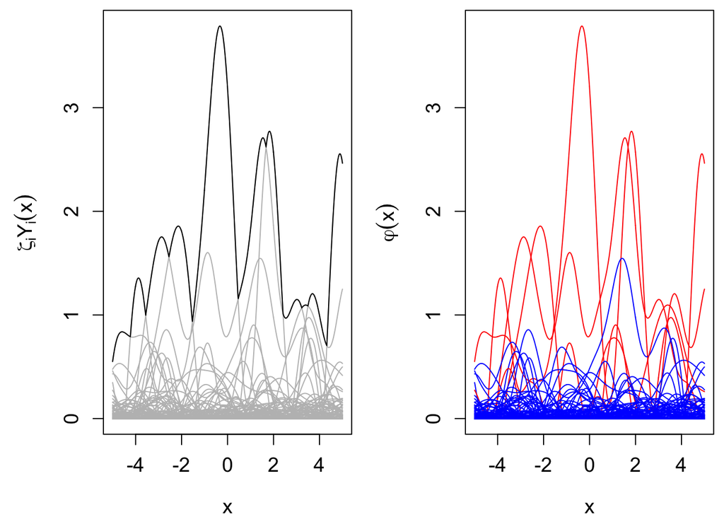

Figure 1.1: Simulation of max table process on [-5,5] from its pectral chracterization.

```r
set.seed(2)
x <- seq(-5, 5, length = 1000)
n.block <- 100

Y <- sqrt(2 * pi) * pmax(rgp(n.block, x, range = 1, smooth = 1.99999), 0)
poisson <- 1 / cumsum(rexp(n.block))

tmp <- poisson * Y
Z <- apply(tmp, 2, max)

par(mar = c(4, 5, 0.5, 0.5), ps = 14, mfrow = c(1, 2))
matplot(x, t(tmp), col = "grey", lty = 1, type = "l",
        ylab = expression(zeta[i] * Y[i](x)))
lines(x, Z, lty = 1)

fun <- function(x) any(x == Z)

idx <- apply(tmp, 1, fun)

col <- c("blue", "red")[1 + idx]
matplot(x, t(tmp), col = col, lty = 1, type = "l",
        ylab = expression(varphi(x)))
```

## 1.4 Spatial extremes for exceedances

Max-stable processes provide models for quantities such as annual maximum rainfall at a number of sites in a region, but in some applications it is preferable to model individual extreme events. In terms of the discussion above, this requires deciding which of the $Q_i (x)$ are to be regarded as extreme, and then basing inference on them, so we need to restrict the **Poisson process** $\{Q_i(x)\}$ to some suitable set $\mathcal{E}'$, for example by taking $\mathcal{E}'=\{q:\rho(q)>1 \}$ for some **risk functional** $\rho$. We might, for example, take

$$\rho_1 (Q)=\sup_{x\in\mathcal{D}}\frac{Q(x)}{z(x)}, \rho_2 (Q) = \inf_{x\in\mathcal{D}}\frac{Q(x)}{z(x)}, \rho_3(Q)=\int_{\mathcal{D}}\frac{Q(x)}{z(x)}dx,$$

corresponding respectively to events that exceed a threshold function $z(x)$ at at least one site in $\mathcal{D}$, those that exceed $z(x)$ everywhere in $\mathcal{D}$ and those for which the average of $\frac{Q(x)}{z(x)}$ over $\mathcal{D}$ is sufficiently large. Thus the type of rare event selected can be tailored to the problem.

Some care is needed in the choice of $\mathcal{E}'$, since likelihood inference involves the integral $\mu(\mathcal{E}')$, which must be both finite and capable of being computed rapidly. If the risk functional satisfies $\rho(aQ)=a\rho(Q)$ for $a>0$, then $\rho(Q)>1$ implies that $R\rho(W)>1$, and then the argument leading to (1.1) can be extended to show that $\mu(\mathcal{E}')=E\{\rho(W)\}$ depends only on the distribution of $W$.

## 1.5 최대안정과정(max-stable process)

최대안정과정은 GEV 분포와 같은 극단값 분포를 공간 상황에서 설명할 수 있게끔 하는 역할을 한다. 앞서 나왔던 **최대안정(max-stable)**의 정의를 다시 살펴보자. 이번엔 (Dey and Yan 2015) 버전이다.

**Definition 1.1 (최대안정과정의 다른 정의)** $Z_{1}, Z_{2},\ldots$를 확률과정 $\{Z(x):x\in\mathcal{X} \}$의 독립인 copy들의 수열이라고 하자. 만약 각각의 $n, (n\geq 1)$에 대해 다음과 같은 $a_{n}>0$, $b_{n}\in\mathbb{R}$이 존재해 다음
$$\begin{equation}
\frac{\max_{i=1,\ldots ,n}Z_{i}-b_{n}}{a_{n}}\stackrel{d}{=}Z
\end{equation}$$
을 만족한다면 $\{Z(x):x\in\mathcal{X} \}$를 **최대안정(max-stable)**하다고 말한다.

다음은 (Haan 1984)에 나오는 정리이다.

**Theorem 1.2 (최대안정과정 관련 정리)** $Y_{1}, Y_{2},\ldots$를 continuous sample path를 갖는 $\{Y(x):x\in\mathcal{X} \}$의 독립인 copy들의 수열이라고 하자. 만약 연속함수 $c_{n}>0, d_{n}\in\mathbb{R}$이 존재해 극한과정(limiting process) $\{Z(x): x\in\mathcal{X}\}$에 수렴한다면, 즉
$$\begin{equation}
\frac{\max_{i=1,\ldots, n}Y_{i}(x)-d_{n}(x)}{c_{n}(x)}\rightarrow Z(x), x\in\mathcal{X}, n\rightarrow \infty
\end{equation}$$
이고 $Z(x)$가 non-degenerate라면 $\{Z(x):x\in\mathcal{X} \}$ **최대안정과정(max-stable process)**이어야 한다. 위 식의 수렴은 $\mathcal{X}$의 연속함수 공간에서의 약수렴(weak convergence)을 의미한다.

이 정리의 의미는 다음과 같다. 일변량 극단값 이론과 연관성을 생각해보면 $\{Z(x):x\in\mathcal{X} \}$는 일반화 극단값 분포여야 한다는 것이다.

공간 극단값 이론에서 최대안정과정을 고려하는 이유는 다음과 같다. $n$개의 독립 반복에서 극한과정(limiting process) $\{Z(x): x\in\mathcal{X}\}$이 $n$이 충분히 클 때 **부분 최대 과정(partial maxima process)**을 모델링 할 좋은 후보라고 여겨지기 때문이다.

**Definition 1.2 (부분 최대 과정)** (margin이 unit Fréchet $(F(z)=\exp(-1/z))$이라고 가정하자.) 이러한 경우에
$$\begin{equation}
\max_{i=1,\ldots , n}n^{-1}Z_{i}(\cdot) \stackrel{d}{=} Z(\cdot), n\geq 1
\end{equation}$$
일 경우 과정(process) $\{Z(x)\}$를 **최대안정과정(max-stable process)**이라고 부른다.

이 때 놀랍게도 최대안정과정에서 **spectral characterization** (뜻 찾아보기)를 얻는 것이 가능하다고 한다.

**Theorem 1.3 (최대안정과정의 spectral characterization)** ((Haan 1984)의 characterization) $\{ (\xi_{i}, U_{i})\}_{i \geq 1}$을 $(0,\infty ] \times \mathbb{R}^{d}$에서 (intensity $d\Lambda (\xi, u)=\xi^{-2}d\xi\nu(du), \nu$는 $\mathbb{R}^{d}$에서 $\sigma$-finite measure)의 **Poisson point process**의 점들이라고 하자. 그리고 $\{Z(x) \}_{x\in\mathbb{R}^{d}}$는 unit Fréchet margin을 가지는 최대안정과정이라고 가정하고 continuous sample path에서
$$\begin{equation}
\{Z(x)\}_{x\in\mathbb{R}^{d}}\stackrel{d}{=}\{\max_{i\geq 1}\xi_{i}f_{x}(U_{i})\}_{x\in\mathbb{R}^{d}}
\end{equation}$$
를 만족한다. 그러면 다음과 같은은 음이 아닌 연속함수
$$\{ f_{x}(y):x,y\in\mathbb{R}^{d}\}$$
가 존재해
$$\begin{equation}
\int_{\mathbb{R}^{d}}f_{x}(y)\nu(dy)=1, \forall x \in \mathbb{R}^{d}
\end{equation}$$
를 만족한다.

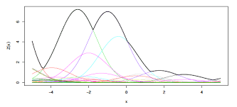

Figure 1.2: de Haans characterization.

이 그림은 de Haan’s characterization을 묘사한 것인데 $\{\xi_{i}\}_{i\geq 1}$이 storm ferocities (아마도 발생 유무를 표시하는 Poisson point process인 듯 하다), $\{\xi_{i}\}_{i\geq 1}$는 storm centers, 그리고 $\xi_{i}f_{x}(U_{i})$은 $i$번째 storm의 $x$지점에서 강수량을 나타낸다고 볼 수 있다. 각각의 함수가 storm event를 묘사한 것일 때, 최대값들을 이은 검은 곡선이 최대안정과정이 되는 것이다.

**Theorem 1.4 (unit Fréchet margin을 가지는 최대안정과정)** ((Schlather 2002)의 characterization) $\{ (\xi_{i}, U_{i})\}_{i \geq 1}$이 $(0,\infty ]$에서 intensity $d \Lambda (\xi)=\xi^{-2}d\xi$를 갖는 **Poisson point process**의 점들이고 $Y_{1},Y_{2},\ldots$를 $E[Y(x)]=1, \forall x \in \mathbb{R}^{d}$ 이고 non-negative continous sample path stochastic process $\{ Y(x)\}$의 independent copy들이라고 하자. 이때 $Y_{i}$들은 $\{ \xi_{i}\}_{i \geq 1}$와 독립이다. 그러면
$$\{ Z(x)\}_{x\in\mathbb{R}^{d}}:=\{\max_{i\geq 1} \xi_{i}Y_{i}(x) \}_{x\in \mathbb{R}^{d}}$$
는 unit Fréchet margin을 가지는 최대안정과정이다.

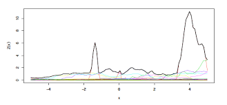

Figure 1.3: Schlathers characterization

이 그림은 Schlather’s characterization을 묘사하고 있는데 앞서 de Haan’s characterization과는 달리 storm center $U_{i}$가 존재하지 않는다. 그렇지만 이 방법은 $f_{x}$라는 함수가 stochastic process로 대채되었으므로 좀 더 다양한 형태의 storm을 모델링 할 수 있다.

### 1.5.1 Smith 모형(Smith model)

첫 번째 제안된 공간 극단값 모형은 (Smith 1990)의 모형이다. 이를 **Smith 과정(Smith process)**이라고 부르기도 한다. (Schlather 2002)에서는 **가우스 극단값 과정(Gaussian extreme value process)**로 언급되었다. 이 모형은
$$\begin{equation}
Z(x)=\max_{i\geq 1}\xi_{i}\phi(x-U_{i};\mathbf{0},\Sigma), x\in\mathcal{X},
\end{equation}$$

이때 $\phi(\cdot, \mathbf{0},\Sigma)$는 평균이 0이고 공분산이 $\Sigma$인 **다변량 정규 확률밀도함수(multivariate Normal density)**이다.

이 모형은 역사적으로는 중요하나 다변량 정규분포의 모양이 너무 제한적, 즉 모형의 유연성(felxibility)이 떨어져 잘 쓰이지는 않는다.

### 1.5.2 Schlather 모형(Schlather model)

Smith 모형이 제안되고 10여년 후, (Schlather 2002)는 **Schlather 과정(Schlather process)**이라는 것을 제안했다. 이 모형은 **극단 가우스 과정(extremal Gaussian process)**으로 불리기도 한다. 이 모형은

$$\begin{equation}
Z(x)=\sqrt{2\pi}\max_{i\geq 1}\zeta_{i}\max\{0,W_{i}(x)\}
\end{equation}$$

로 이때 $\{W_{i}(x): x\in\mathcal{X}\}$는 상관함수(correlation function) $\rho$를 갖는 **정상 가우스과정(staionary Gaussian process)**의 독립된 copy들이다. 또한 척도요인(scaling factor) $\sqrt{2\pi}$는 모든 $x\in\mathcal{X}$에 대해 $\sqrt{2\pi}E[\max\{ 0,W(x)\}]=1$를 만족해야 한다.

이 모형은 후술할 모형들에 비해 큰 값이 나오는 지역이 더 많은데 그 이유는 **공간 독립(spatial independence)**이 요구되지 않는 모형이기 때문이라고 한다.

### 1.5.3 Brown-Resnick 모형(Brown-Resnick model)

이 모형은 (Brown and Resnick 1977)이 처음 제안하였고 (Kabluchko, Schlather, and Haan 2009)가 일반화하였다. **Brown-Resnick 과정(Brown-Resnick process)**는

$$\begin{equation}
Z(x)=\max_{i\geq 1}\xi_{i}\exp\{W_{i}(x)-\gamma(x)\},x\in\mathcal{X}
\end{equation}$$

으로 정의된다. 이때 $\{W_{i}(x): x\in\mathcal{X}\}$는 평균이 0이며 정상증분(stationary increments)을 갖고 준변동도(semi-variogram)이 $\gamma(h)=\text{Var}\{W(x+h)-W(x)\}/2$인 가우스 과정(Gaussian process)의 독립된 cpoy들이다. 한편 Smith 모형은 위 식의 특별한 케이스로,

$$W(x)=x^{T}\Sigma^{-1}X, X\sim\mathcal{N}(0,\Sigma)$$
이며 $2\gamma(x)=x^{T}\Sigma^{-1}\text{Var}(X)\Sigma^{-1}x=x^{T}\Sigma^{-1}x$인 경우라고 볼 수 있다.

### 1.5.4 극단-t 모형(extremal-t model)

**극단-t 과정(extremal-t process)**는 이것의 **스펠트럴 특성화(spectral representation)**이 최종적으로 (Opitz 2013)에 의해 유도되었다.

$$\begin{equation}
Z(x)=c_{\nu}\max_{i \geq 1}\zeta_{i}\max\{0,W_{i}(x)\}^{\nu}, x\in\mathcal{X}
\end{equation}$$

이며 $\nu \geq 1$, $\{W_{i}(x):x\in\mathcal{X}\}$는 상관함수가 $\rho$이며
$$c\nu =\sqrt{\pi}2^{-(\nu-2)/2}\Gamma(\frac{\nu+1}{2})^{-1}$$
인 정상 가우스 과정의 독립된 copy들이다.

### 1.5.5 Other spatial extreme models

Max-stable processes may be modified in various ways. For example, skew-normal and skew-t processes can be used, rather than Gaussian or t-processe, and these may be useful when asymmetries are present (Beranger, Padoan, and Sisson 2016).

Another extension is multiplication by the indicator of a random compact set $\mathcal{B}$ independent of $W(\cdot)$, resulting in

$$W_{\mathcal{B}}(x)= W(x) \frac{I(x\in\mathcal{B})}{E(|\mathcal{B}|)}, \qquad{x\in\mathcal{X},}$$

where the expectation $E(|\mathcal{B}|)$ must be finite in order to ensure that $E\{W_{\mathcal{B}}(x)\}\equiv 1$. If we write $\alpha(x_1, x_2)=P(x_1, x_2\in\mathcal{B})$, then it is straightforward to check that the corresponding exponent function is

$$\{1-\alpha(x_1, x_2) \}\Bigg(\frac{1}{z_1} + \frac{1}{z_2} \Bigg)+\alpha(x_1,x_2)V(z_1,z_2).\qquad{z_1,z_2>0.}$$

Thus if, for example $\mathcal{B}$ is a disk of fixed diameter $L$ centered at a point uniformly distributed on $\mathcal{X}$, then $x_1$ and $x_2$ cannot both lie in $\mathcal{B}$ when $\|x_1 - x_2\| > L$, and $Z(x_1)$ and $Z(x_2)$ must be independent, whereas if $x_1 \approx x_2$, then the exponent function will almost be that of the max-stable process based on $W$. Huser and Davison (2013) use this idea to model extreme hourly rainfall; their random sets are stylized representations of the space-time extent of rainfall cells, each containing an independent process $W(x)$.

Yet more processes may be constructed by letting $W(x)=\frac{f(x;Y)}{f_y(Y)}$, where $Y$ has density $f_y$ on some space $\mathcal{Y}$, and $\int_{\mathcal{Y}} f(x;y)dy=1$ for each $x$. The simplest such model, the **Smith process**, has $\mathcal{Y}=\mathcal{X}=\mathbb{R}^{k}$, $f_y(y)$ an arbitrary density supported on $\mathbb{R}^k$ and $f(x;y)=\phi_k(x-y;\Omega)$, where $\phi_k(\cdot;\Omega)$ is the $k$-variate Gaussian density with covraince matrix $\Omega$. The corresponding random functions $Q(x)=RW(x)$ consist of $k$-variate Gaussian densities centered at random points of $\mathbb{R}^{k}$, whose shape is determined by $\Omega$ and whose maximum height is determined by $R$ and $|\Omega|$. These and similar processes obtained by using other standard probability density functions are typically too smooth to be realistic in applications.

## 1.6 극단값의 공간 종속성(spatial dependence of extremes)

공간통계학에서 쓰이는 변동도(variogram)을 다시 정의해보면

$$\begin{equation}
\frac{1}{2}E[\{Z(x_{1})-Z(x_{2}) \}^{2}], x_{1}, x_{2} \in \mathcal{X}
\end{equation}$$

이다. 그러나 공간 극단값 이론에서는 분산 또는 평균조차도 존재하지 않을 수 있다. 다행히도 (Cooley, Naveau, and Poncet 2006)이 **F-매도그램(F-madogram)**이라는 적절한 툴을 제공하였다. 이것의 정의는 다음과 같다.

$$\begin{equation}
\nu_{F}(h)=\frac{1}{2}E[|F\{Z(x+h)\}-F\{Z(x)\}], x,h\in \mathcal{X}.
\end{equation}$$

여기서 $F$는 $Z(x), x\in\mathcal{X}$의 cdf를 의미한다. (준)변동도와는 달리, F-매도그램은 $F\{Z(x)\} \sim U(0,1)$이므로 잘 정의가 되며 기댓값은 $1/2$을 갖는다. 또한 F-매도그램은 **극단계수함수(extremal coefficient function)**와 강한 연관성을 갖기 때문에 공간 극단값 분석시 유용하다. 극단계수함수는
$$\theta : h \rightarrow E[\max \{ Y(x),Y(x+h) \}]$$
$$\begin{align*}
P\{Z(x+h)\leq z | Z(x)\leq z\}&=P\{Z(x+h)\leq z\}^{\theta(h)-1}\nonumber\\
&=
\begin{cases}
1 & \text{perfect dependence}\\
P\{Z(x+h)\leq z\} & \text{independence}
\end{cases}
\end{align*}$$

# 2 최대안정 임의장

우리는 때때로 어떤과정의 극단적으로 높거나 낮은 수준을 모델링하는 데 관심을 갖을 수도 있다. 공간 또는 시공간 극단값의 무작위 행동을 분석하는 한 가지 방법이 **최대안정 임의장(max-stable random fields)**이다.

우선 간단하게 spatial case만 살펴보자. $\{Y(\mathbf{s})\}_{\mathbf{s}\in\mathcal{S}}$가 continuous sample path를 갖는 정상 임의장이라고 하고 $Y_{1},\ldots, Y_{n}$을 그것의 $n$개의 복사본이라고 하자. 다음과 같은 pointwise maximum process
$$M_{n}(\mathbf{s}):=\max_{i=1,\ldots,n}Y_{i}(\mathbf{s}), \mathbf{s}\in\mathcal{S}$$
를 생각해보자. 만약 모든 $\mathbf{s}\in\mathcal{S}$에 대해 연속함수 $a_{n}(\mathbf{s})>0$, $b_{n}(\mathbf{s})\in\mathbb{R}$이 존재해
$$\frac{M_{n}(\mathbf{s})-b_{n}(\mathbf{s})}{a_{n}(\mathbf{s})} \stackrel{\text{converge weakly}}{\rightarrow}Z(\mathbf{s})$$
하고 이때 $Z(\mathbf{s})$가 모든 임의의 $\mathbf{s}\in\mathcal{S}$에 대해 non-degenerate marginal distribution을 갖는다면 이 때 $Z$는 **최대안정 임의장(max-stable random fields)**이 된다.

어떤 $\mathbf{s}\in\mathcal{S}$에 대해 최대안정 임의장은 **일변량 주변 일반화 극단값 분포(univariate marginal generalized extreme value distribution)**을 갖으며 유한한 장소의 집합에 대한 결합분포는
$$P\{Z(\mathbf{s}_{j})\leq z_{j}, j \in J\}=e^{-V(\mathbf{z})},$$
$$V(\mathbf{z})=k\int_{\Delta_{k-1}}\max_{j\in J}(\frac{\omega_{j}}{y_{j}})\nu(d\mathbf{w}), \mathbf{z}\in\mathbb{R}_{+}^{k}$$
로 정의된다. 여기서 $\nu$는 $(k-1)$ 차원 unit simplex $\Delta_{k-1}$에서 정의된 확률분포이며 $V$는 **지수종속함수(exponent dependece function)**이라고 불린다.

다음은 최대안정 임의장들의 예이다. 이들의 차이는 지수종속함수의 차이로부터 발생한다.

## 2.1 Brown-Resnick 임의장(Brown-Resnick random fields)

**Brown-Resnick 임의장(Brown-Resnick random fields)**의 이변량분포(bivariate distribution)의 지수종속함수는

$$\begin{equation}
V_{1}(z_{1},z_{2};\mathbf{h})=\frac{1}{z_{1}}\Phi (\frac{\lambda(\mathbf{h})}{2}+\frac{\log z_{2}/z_{1}}{\lambda(\mathbf{h})}) + \frac{1}{z_{2}}\Phi (\frac{\lambda(\mathbf{h})}{2}+\frac{\log z_{1}/z_{2}}{\lambda(\mathbf{h})})
\tag{2.1}
\end{equation}$$

이다. 여기서 $\lambda(\mathbf{h})=\sqrt{2\gamma(\mathbf{h})}$이며 $\gamma$는 가우스 임의장 하의 준변동도(semivariogram)이다. 위 식의 유도는 (Hüsler and Reiss 1989)와 (Smith 1990)에 있다. 지수종속함수의 시공간 버전은 (Kabluchko 2009) 및 (Davis, Klüppelberg, and Steinkohl 2013)을 참조하길 바란다.

## 2.2 Extremal-Gaussian 임의장(extremal-Gaussian random fields)

**Extremal-Gaussian 임의장(extremal-Gaussian random fields)**의 이변량분포(bivariate distribution)의 지수종속함수는
$$V_{2}(z_{1},z_{2};\mathbf{h})=\frac{1}{2}(\frac{1}{z_{1}}+\frac{1}{z_{2}})(1+[1-\frac{2z_{1}z_{2}\{\rho(\mathbf{h})+1\}}{(z_{1}+z_{2})^{2}}]^{1/2})$$
이며 $\rho(\mathbf{h})$는 가우스 임의장(Gaussian random fields)에 있던 상관관계함수이다.

## 2.3 Extremal-t 임의장(extremal-t random fields)

**Extremal-t 임의장(extremal-t random fields)**의 이변량분포(bivariate distribution)의 지수종속함수는

$$\begin{equation}
V_{3}(z_{1},z_{2};\mathbf{h})=\frac{1}{z_{1}}T_{\nu+1}\{\frac{(z_{2}/z_{1})^{1/\nu}-\rho(\mathbf{h})}{\sqrt{\{ 1-\rho(\mathbf{h})^{2} \}/(\nu+1) }}\} + \frac{1}{z_{2}}T_{\nu+1}\{\frac{(z_{1}/z_{2})^{1/\nu}-\rho(\mathbf{h})}{\sqrt{\{ 1-\rho(\mathbf{h})^{2} \}/(\nu+1) }}\}
\tag{2.2}
\end{equation}$$

으로 여기서 $T_{\nu+1}$는 자유도 $\nu+1$을 같는 스튜던트-t 분포이며 $\rho(\mathbf{h})$는 압축함수(scaling function)이고 $\nu$는 Student-t random field의 자유도이다.

```r
set.seed(1)

x <- y <- seq(-5, 5, length = 250)

smith <- rmaxstab(1, cbind(x, y), "gauss", cov11 = 1, cov12 = 0, cov22 = 1, grid = TRUE)
schlat <- rmaxstab(1, cbind(x, y), "powexp", nugget = 0, range = 2, smooth = 1.5, grid = TRUE)
extt <- rmaxstab(1, cbind(x, y), "tpowexp", nugget = 0, range = 4, smooth = 1.5, DoF = 5,
                 grid = TRUE)

model <- RMfbm(alpha=1.5,scale = 2)
brown <- RFsimulate(RPbrownresnick(model), x=x, y=y, grid = TRUE, n=1)
```

```
## New output format of RFsimulate: S4 object of class 'RFsp';
## for a bare, but faster array format use 'RFoptions(spConform=FALSE)'.
```

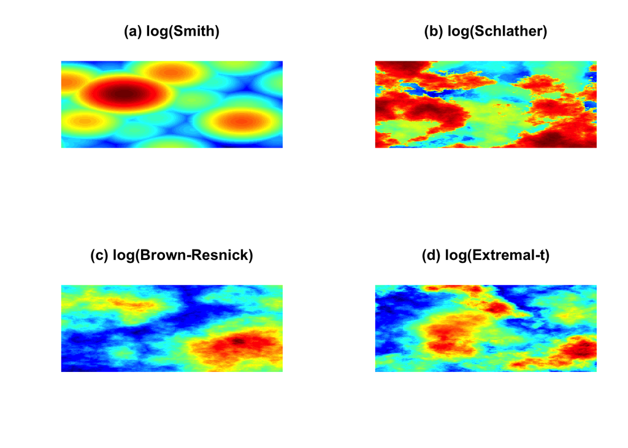

Figure 2.1: One realization on a grid from each of the max-stable mofels, (a) Smith, (b) Schlather, (c) Brown-Resnick, and (d) Extremal-t

```r
brown <- as.matrix(brown)

col <- tim.colors(64)

version <- 1
if (version == 1){
    #par(mfrow = c(1,4), mar = rep(0.2, 4))
    par(mfrow = c(2,2))
    image(log(smith), axes = FALSE, col = col, main="(a) log(Smith)")
    image(log(schlat), axes = FALSE, col = col, main="(b) log(Schlather)")
    image(log(brown), axes = FALSE, col = col, main="(c) log(Brown-Resnick)")
    image(log(extt), axes = FALSE, col = col, main="(d) log(Extremal-t)")
}
```

```r
if (version == 2){
    #par(mfrow = c(1,4), mar = rep(0.2, 4))
    par(mfrow = c(2,2))
    zlim <- range(c(smith, schlat, brown, extt))
    zlim <- log(zlim)
    breaks <- seq(-8, 16.5, length = 65)

    for (i in 1:4){
        if (i == 1)
            z <- log(smith)

        if (i == 2)
            z <- log(schlat)

        if (i == 3)
            z <- log(brown)

        if (i == 4)
            z <- log(extt)

        zfacet <- z[-1, -1] + z[-1, -250] + z[-250, -1] + z[-250, -250]
        print(range(zfacet))
        facetcol <- cut(zfacet, breaks)

        persp(x, y, z, col = col[facetcol], phi = 30, theta = -30, axes = FALSE,
              box = FALSE, border = NA, zlim = zlim, shade = .2)
    }
}
```

(그림설명)

One realization on a $250\times 250$ grid from each of the max-stable models introduced in this article. (a) Smith where $\Sigma$ is the identity matrix, (b) Schlather with $\rho(h) = \exp\{-(\frac{h}{2})^{1.5} \}$, (c) Brown-Resnick with $\gamma(h)=(\frac{h}{2})^{1.5}$, and (d) Extremal-t with $\nu=5$ and $\rho(h) = \exp \{ -(\frac{h}{4})^{1.5}\}$. Note that for visualization purposes the margins were transformed to standard Gumbel margins. (TRUE?)

## 2.4 Asymptotic independence in spatial extremes

Most of the models described aboe presuppose that the transformed extremes of the phenomenon under investigation are **asymptotically dependent**, i.e.,

$$\begin{equation}
\lim_{z\rightarrow\infty}P\{Z(x_2)>z|Z(x_1)>z \}=2-\theta(x_1,x_2)>0, \qquad{x_1,x_2\in\mathcal{X},}
\tag{2.3}
\end{equation}$$

An intermediate possibility is needed, whereby the limit in (2.3) is zero, but the conditional probability decreases as $z\rightarrow\infty$. This is often plausible from physical arguments and is common in applications, of which it can be an important feature. Such **asymptotic independence** models are a topic of current research.

## 2.5 Exploratory procedures for spatial extremes

Simple nonparametric estimation procedures are valuable for initial analysis and for checking the validity of fitted models. Most are based on pairs of extremal obaservations, which offer direct insight into the dependence structure of the data, in analogy with quantities such as the variogram of classical geostatistics, which is defined in terms of the average squared difference between observations.

Since extremal observations need not possess moments, a rank-based approach is preferable. Suppose that observations $Z_1\equiv Z(x_1)$ and $Z_2\equiv Z(x_2)$ at sites $\mathcal{D}=\{x_1, x_2\}\in\mathcal{X}$ arise from a simple max-stable process. A natural measure of the dependence between $Z_1$ and $Z_2$ is the **extremal coefficient** $\theta_{\mathcal{D}}$ defined in (1.9); we have $\theta_{\mathcal{D}}\in [1,2]$, with smaller values corresponding to stronger dependence, so we can expect $\theta_{\mathcal{D}}$ to increase as the distance $\|x_1-x_2\|$ grows.

```r
data(rainfall)

toto <- fmadogram(rain, coord[,1:2], n.bins = 200)
```

[figure not shown]

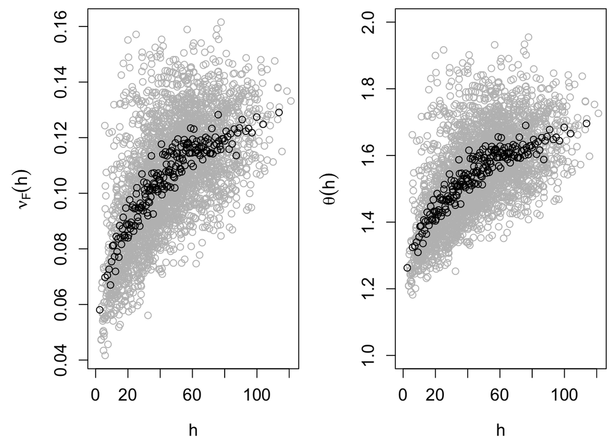

Figure 2.3: Empirical F-madogram (left) and corresponding extremal coefficients (right) of the Swiss precipitation data of the `SpatialExtremes` package. The gray points are pairwise estimates while the black ones are binned estimates obtained from 200 bins.

```r
par(mfrow = c(1, 2), mar = c(4, 5, 0.5, 0.5), ps = 14)
fmadogram(rain, coord[,1:2], col = "grey", which = "mado")
points(toto[,"dist"], toto[,"madogram"])

fmadogram(rain, coord[,1:2], col = "grey", which = "ext")
points(toto[,"dist"], toto[,"ext.coeff"])
```

Estimation of $\theta_{\mathcal{D}}$ may be based on the **F-madogram**,

$$\psi_{\mathcal{D}}=\frac{1}{2}E\{ |F(Z_1) - F(Z_2)| \},$$

where $F(z)=e^{-\frac{1}{z}}$ $(z>0)$ is the **standard Frechet distribution**. Since $|a-b|=2\max(a,b)-a-b$, and the distribution functions of $Z_1, Z_2$ and $\max(Z_1, Z_2)$ are respectively $F(z)$, $F(z)$ and $e^{-\frac{\theta_{\mathcal{D}}}{z}}$ $(Z>0)$, it is straightforward to check that $\phi_{\mathcal{D}}=\frac{1}{2}\frac{(\theta_{\mathcal{D}}-1)}{(\theta_{\mathcal{D}}+1)}$ and therefore that

$$\theta_{\mathcal{D}} = \frac{1+2\psi_{\mathcal{D}}}{1-2\psi_{\mathcal{D}}}.$$

An estimator $\hat{\theta}_{\mathcal{D}}$ based on independent pairs $(Z_{1,1}, Z_{2,1}), \ldots, (Z_{1,n}, Z_{2,n})$ may be obtained by replacing $F(Z_1)$ by the rank estimator $\frac{R_{1,j}}{n+1}$ $(j=1,\ldots,n)$, where $R_{1,j}$ is the rank of $Z_{1,j}$ among $Z_{1,1},\ldots, Z_{1,n}$, and likewise with $F(Z_2)$, and then replacing $\psi_{\mathcal{D}}$ by $\frac{1}{2n(n+1)}\sum_{j=1}^{n}|R_{1,j}-R_{2,j}|$, its empirical counterpart.

If the underlying process is stationary, then $\theta_{\mathcal{D}}$ depends only on $h=x_1-x_2$, so a plot of the $\hat{\theta}_{\mathcal{D}}$ for all possible pairs of points $\mathcal{D}$ can be smoothed or binned and used for dignostic or confirmatory purposes. As in the classical case, some care must be taken in interpreting such plots, since data from $D$ underlying sites yield a cloud of$\frac{D(D-1)}{2}$ correlated estiamtes $\hat{\theta}_{\mathcal{D}}$; moreover these empirical estimates may be very variable.

The anticipated increase in $\theta_{\mathcal{D}}$ with $\|x_1-x_2\|$ makes a natural analogy with the variogram, but since $P(Z_2>z|Z_1>z)\sim 2- \theta_{\mathcal{D}}$ as $z\rightarrow\infty$, the quantity $2-\theta_{\mathcal{D}}$ may be interpreted as the probability of a large event at $x_2$ given a correspondingly large event at $x_1$.

A plot of $2-\hat{\theta}_{\mathcal{D}}$ against distance is known as an **extremogram**, analogous to the correlogram of classical time series analysis, and has been proposed for use particularly with time series; resampling can be used to gauge which probabilities are indistinguishable from zero. **Cross-extremograms** or extremes of two or more series can also be defined, but like cross-correlograms, they are vulnerable to spurious correlations for which allowance must be made.

Th conditional probability $2-\theta_{\mathcal{D}}$ has a natural interpretation for **asymptotically dependent processes**, but equals zero for **asymptotically independent processes**, whatever their rate of tail decay, so it is natural to seek a measure of asymptotic independence.

As many standard models are based on underying Gaussian processes, which are defined in terms of their first and second moments, standard fitting procedures will tend to match these to the data, either explicitly or implicitly. We might therefore expect theoretical and emprical estimates of pairwise quantities, such as the extremal coefficient $\theta(h)$ of two sites a distance $h$ apart, to match well enough to make model failure more difficult to detect. This suggests using higher-order, in addition to pairwise, quantities for checking model fit. For example, if $\mathcal{D}=\{x_1, \ldots, x_D\}$ is a subset of sites, then it is easy to see that $\max_{x\in\mathcal{D}}Z(x)$ has the Frechet distribution $e^{-\frac{\theta_{\mathcal{D}}}{z}}$. Thus we might compare quantities of the observed maxima for $\mathcal{D}$ with those from a fitted model, for sets $\mathcal{D}$ that are spatially close or sptially far-flung; if the fitted model is adequate, the empirical and simulated distributions should match. Similarly, empricial probabilities of certain spatial events invoving more than two sites could be compared with estimates based on the model.

## 2.6 Inference of spatial extremes

Although there is a growing literature on non-parametric inference for extremal processes, parametric modelling is most used in applications. One reason for this is that it is usually more straightforward to interpret a parametric model, and a second is that a common goal of fitting such processes to data is the estimation of rare event probabilities. Typically this is performed by Monte Carlo simulation from one or more fitted models, which may be easier for a parametric model.

Statistical estimation for extreme values is always subject to mis-specification bias, since the classes of models fitted are typically based on asymptotic arguments that do not apply to the data themselves. It can be hard to detect lack of fit, because extremal models tend to be rather flexible and power for goodness-of fit assessment is limited owing to the small number of extreme events. Moreover the uncertainty surrounding extrapolation to events even rarer than those already observed is typically so large that bias is a secondary consideration. It is essential to assess the sensitivity of conclusions both to the choice of the model and to the degree of ‘extremeness’ of the data: this entails checking that the fitted models do not change greatly when the threshold or block size is varied over a reasonable range.

Below we focus on likelihood-based estimation, but other proposals include robust estimation based directly on the joint distribution function, approximate Bayesian computation, and score-based methods.

$$Z(x;\varphi)=[1+\xi(x;\varphi)\frac{\{ Y(x)-\eta(x;\varphi) \}}{\tau(x;\varphi)} ]_{+}^{\frac{1}{\xi(x;\varphi)}},$$

where $Y(x)$ is the observed maximum at $s$ and $Z(x,\varphi)$ has a **standard Frechet distribution**, the joint probability density function of $Y(x_1),\ldots, Y(x_D)$ can be written in terms of the standardized variables

$$z(x_d;\varphi)=[1+\xi(x_d ;\varphi)\frac{\{ y_d -\eta(x_d ;\varphi) \}}{\tau(x_d ;\varphi)} ]_{+}^{\frac{1}{\xi(x_d ;\varphi)}}, \qquad{d=1,\ldots, D,}$$

as

$$\begin{equation}
f_{Z(x_1),\ldots, Z(x_D)}\{z(x_1;\varphi), \ldots, z(x_D;\varphi)l\theta \}\times \prod_{d=1}^{D}\frac{dz(x_d;\varphi)}{d y_d}
\tag{2.4}
\end{equation}$$

where $\theta$ represents parameters in the joint distribution of the $Z$s and the second term is a Jacobian.

Maximum likelihood estimation will involve maximizing a product of expressions of the form (2.4), for example with a term for each different year of observed maxima, over bothe $\varphi$ and $\theta$. computational considerations may entail the estimation of $\varphi$ separately from $\theta$ in a two-step procedure, though in principle this is undesirable because an overall measure allowing for the uncertainty of both $\hat{\theta}$ and $\hat{\varphi}$ is then awkward to obtain. In the applications below we found it necessary to use this two-step approach, but then obtained a combined assessment of uncertainty by applying it to bootstrap datasets obtained by resampled subsets of the original ata that could be taken as independent. Initial values for $\varphi$ can be obtained by maximizing an independent likelihood, which uses the same smooth functions for spatial variation of marginal parameters $\eta$, $\tau$, and $\xi$ as in (2.4), but treats the $Z$s as independent standard Frechet variables. Similar computations are needed for likelihoods based on copulas.

### 2.6.1 Likelihood inference for spatial maxima

We now discuss the computation of the first term in (2.4) in the case of inference based on maxima. The key problem is that this involves $D$-fold differentiation of the joint cummulative distribution function (1.8), resulting in a combinatorial explosion. For example, with $D=3$, we have

$$\begin{equation}
f(z_1,z_2,z_3;\theta)=e^{-V}(-V_{123}+V_{1}V_{23}+V_{2}V_{13}+V_{3}V_{12}-V_{1}V_{2}V_{3})
\tag{2.5}
\end{equation}$$

using shorthand notation in which

$$V=V(z_1,z_2,z_3;\theta), V_d=\frac{\partial V (z_1,z_2,z_3;\theta)}{\partial z_d}, V_{d_1,d_2}=\frac{\partial^2 V(z_1,z_2,z_3;\theta)}{\partial_{z_{d_1}}\partial_{z_{d_2}}},$$

and so forth. The number of terms in the density is the number of partitions of the set $\mathcal{D}$, with $\mathcal{D}=\{x_1,x_2,x_3\}$ there are five such partitions, corresponding to the terms on the right-hand side of (2.5), but with $D=10$ there are around $10^5$ terms. Thus in realistic setting it is infeasible to compute the full likelihood, and a number of ways to avoid doing so have been proposed.

**Composite likelihood** inference uses simpler likelihood components. The most common is a pairwise likelihood, in which the components involve only pairs of observations, for example replacing (2.5) by

$$\begin{equation}
f(z_1, z_2;\theta)\times f(z_1, z_3;\theta)\times f(z_2, z_3;\theta).
\tag{2.6}
\end{equation}$$

Here only bivariate exponent functions such as (2.1) and (2.2) and their first and second derivatives are needed. For this approach to be useful, $\theta$ must be identifiable from the chosen marginal distributions, as is generally the case with Gaussian-based models. Although maximizing a composite likelihood yields consistent estimator, $\hat{\theta}_{C}$, say, measures of uncertainty and tools for model comparison must compensate for the re-use observations in terms such as (2.6). For example, if $z_1, z_2, z_3$ were independent, then (2.6) would equal $\{ f(z_1;\theta)f(z_2;\theta)f(z_3;\theta) \}^2$, i.e., the square of the correct likelihood contribution, and although $\hat{\theta}_{C}$ would then equal the usual maximum likelihood estimate, standard errors based on the observed information matrix $\hat{J}$ would be too small by a factor $\sqrt{2}$.

Standard errors for $\hat{\theta}_{C}$ can be obtained by resampling or using a ‘sandwich’ variance matrix $\hat{J}^{-1}\hat{K}\hat{J}^{-1}$. Suppose that the data fall into independentblocks indexed by $i\in\mathcal{I}$, and that the $i$-th block consists of dependent observations $z_{i,d}$. In many cases $\mathcal{I}$ will correspond to data from different years or extreme evnets, assumed to be independent, whereas the data $z_{i,1}, \ldots, z_{i,D}$ for block $i$ are likely to be dependent. Then with $l_{1;d',d}=\log f(z_{i,d'}, z_{i,d};\theta)$ and pairwise likelihood $\sum_{i}\sum_{d'<d}l_{i;d',d}(\theta)$, we have

$$\hat{K} = \sum_{i\in\mathcal{I}}\sum_{d'<d}\frac{\partial l_{i;d',d}(\theta)}{\partial \theta}\frac{\partial l_{i;d',d}(\theta)}{\partial \theta^T}|_{\theta=\hat{\theta}_{C}}, \hat{J}= -\sum_{i\in\mathcal{I}}\sum_{d'<d}\frac{\partial^2 l_{i;d',d}(\theta)}{\partial\theta\partial\theta^T}|_{\theta=\hat{\theta}_{C}}.$$

Data are often missing from some blocks, and then the internal sum is taken over only those pairs available for that block. The matrix $\hat{K}$ can be unstable, and then resampling of blocks to obtain standard errors is preferable, even though it can be slow.

In some cases the computational burden can be recduced and the statistical properties of $\hat{\theta}_{C}$ can be enhanced by weighting likelihood constributions $l_{i;d',d}(\theta)$, for example downweighting pairs that are spatially distant, since these might be expected to contribute less information.

Models are computed using **composite likelihood information criterion**, $\text{CLIC}=2\{\text{tr}(\hat{J}^{-1}\hat{K})-\hat{l}_{C}\}$, where $\hat{l}_{C}$ is the maximum log-composite likelihood; low values of CLIC are preferred. The re-use of observations can lead to very large values of CLIC, and it may be useful to rescale it for comparability with standard information criteria such as AIC; In (2.6), for example, the log likelihood contribution should be halved, and if there were $D$ maxima, it would be divided by $D-1$.

A second solution to the explosion of terms in expression such as (2.5) stems from noticing that the terms in expressions such as the right-hand side of (2.5) correspond to different ways in which the extremes can occur: the first corresponds to a single event leading to all three maxima, the last to maxima from three separate events, and the others to the ways in which three maxima might arise from two separate events. Thus if it was known that $z_1$ arose from one event, whereas $z_2$ and $z_3$ occurred together, then the appropriate likelihood contribution would be $V_{1}V_{23}e^{-V}$ rather than the whole of (2.5). If the required derivatives of $V$ are available then the resulting likelihood is computationally feasible even in high-dimensional cases, but the resulting maximum likelihood estimators depend on the choice of partition and can be badly biased if this choice is wrong.

In practice, an empirical **declustering** rule is typically used to estimate the partition, and the approach does not seem to be very robust. It can be improved by estimating the partition in a more formal way, either using a **stochastic EM algorithm**, or, in a Bayesin context, by including the partition in a **Monte-Carlo sampling algorithm**, and then integrating over it.

### 2.6.2 Likelihood inference for spatial threshold exceedances

Analysis of individual events, typiclly those exceeding some suitable threhold, allows more detailed modelling and more precise inferences than analysis of maxima, and is particularly useful when assessing simultaneous risks. In principle, the approach based on the Poisson process approximation using a parametric measure $\mu_{\theta}(\cdot)$ is straightforward: a set $\mathcal{E}'$ having finite measure is chosen to select rare events, and then estimation is based on a **Poisson process likelihood**.

Suppose, for example, that events $q_1,\ldots, q_n$ have been observed at $D$ points $x_1, \ldots, x_D$, so that $q_j \equiv \{ q_{j}(x_1), \ldots , q_{j}(x_D) \}$, and that $\mathcal{E}'=\{ q: \rho(q)> 1 \}$ for some functional $\rho$. Then the selected data will be those $q_j$ for which $\rho(q_j)>1$, say $q_{1}', \ldots, q_{n}'$, and the likelihood is

$$\begin{equation}
L_{\text{Pois}}(\theta)=e^{-\mu_{\theta}(\mathcal{E}')}\times \prod_{j=1}^{n'}\dot{\mu}_{\theta}(q_{j}'),
\tag{2.7}
\end{equation}$$

where $\dot{\mu}_{\theta}(q)$ denotes the Poisson process intensity evaluated at $q$. If $\rho(q)=\sum_{d=1}^{D}\frac{q(x_d)}{u_d}$ for some $u_1, \ldots, u_D >0$, then $\mathcal{E}'=\{ (r,w):\sum_{d=1}^{D}r\frac{w(x_d)}{u_d} >1 \}$ and $\mu_{\theta}(\mathcal{E}')$ is a constant, so only the second term on the right-hand side of (2.7) is needed; it is known asthe **sprectral likelihood**, though perhaps **angular likelihood** would be a better term. Its drawback is that the events $q_{j}'$ thus chosen may have some very small components, making the extremal approxiamtion questionable.

An alternative ensuring that all events are far from the axes wouldbe to take $\rho(q)=\min_{d}\frac{q(x_d)}{u_d}$, but this can greatly reduce the number of events available for estimation, especially if extremal dependence is weak. We therefore often take $\rho(q) = \max_{d}\frac{q(x_d)}{u_d}$, but use a **censored likelihood** to avoid including the exact values of small components, as we now describe. This uses less precise information and thus decreases the precision of our estimates, but it reduces the bias due to inclusion of non-extreme values.

Censored likleihood is most easily explained in the bivariate case, where $\mathbb{R}_{+}^{2}$ is partitioned into four regions $\mathcal{R}_{I_1, I_2}$, corresponding to the values of the indicators $I_1 = I(Q_1 > u_1)$ and $I_2 = I(Q_2 > u_2)$ of the events that the $Q_d$ exceed thresholds $u_d$. If $I_1 = I_2 = 1$, i.e., both variables exceed the thresholds, then $q\in\mathcal{R}_{1,1}$, the extremal model is regarded as valid and the likelihood contribution from $q=(q_1, q_2)$ is $\dot{\mu}_{\theta}(q)$. If $I_1 = 1, I_2 = 0$, then $q\in\mathcal{R}_{1,0}$, so the precise value of $q_1$ is used but $q_2$ is left-censored at $u_2$, giving likelihood contribution $\int_{0}^{u_2}\dot{\mu}_{\theta}\{ (q_1, y) \} dy$. Likewise when $I_1 =0, I_2 = 1$, the likelihood contribution is $\int_{0}^{u_1}\dot{\mu}_{\theta}\{ (x,q_{2} ) \} dx$. If $I_{1} = I_{2} = 0$, then $q \in \mathcal{R}_{0,0}$, where the extremal model cannot be trusted, so we use a **Poisson process likelihood** with region $\mathcal{E}' = \mathbb{R}_{+}^{2}\backslash \mathcal{R}_{0,0}=\mathcal{E}_{u}$, say, thus having censored contributions from $\mathcal{R}_{0,1}$ and $\mathcal{R}_{1,0}$ and uncensored constributions from $\mathcal{R}_{1,1}$. This likelihood involves computation of $\mu(\mathcal{E}_{u})=V(u_1, u_2),$ where $V$ is the **exponent function** corresponding to $W(x)$; see (1.8). One can check that $\dot{\mu}_{\theta}(q) = - \frac{\partial^2 V(q_1, q_2)}{\partial q_1 \partial q_2}$ and that the terms needed for the censored contributions have forms such as $-\frac{\partial V(u1, q_2)}{\partial q_2}$, with obvious extensions to higher dimensions.

Alan Gelfand, Jennifer A. Hoeting, Montse Fuentes. 2019. *Handbook of Environmental and Ecological Statistics*. Taylor & Francis Inc. https://www.ebook.de/de/product/36273451/handbook_of_environmental_and_ecological_statistics.html.

Beranger, Boris, Simone A. Padoan, and Scott A. Sisson. 2016. “Models for Extremal Dependence Derived from Skew-Symmetric Families.” *Scandinavian Journal of Statistics* 44 (1): 21–45. https://doi.org/10.1111/sjos.12240.

Brown, Bruce M., and Sidney I. Resnick. 1977. “Extreme Values of Independent Stochastic Processes.” *Journal of Applied Probability* 14 (4): 732–39. https://doi.org/10.2307/3213346.

Coles, Stuart. 2011. *An Introduction to Statistical Modeling of Extreme Values*. Springer London. https://www.ebook.de/de/product/13423684/stuart_coles_an_introduction_to_statistical_modeling_of_extreme_values.html.

Cooley, Dan, Philippe Naveau, and Paul Poncet. 2006. “Variograms for Spatial Max-Stable Random Fields.” In *Dependence in Probability and Statistics*, edited by Patrice Bertail, Paul Doukhan, and Philippe Soulie, 187:373–90. Lecture Notes in Statistics. Springer Science; Business Media.

Davis, Richard A., Claudia Klüppelberg, and Christina Steinkohl. 2013. “Max-Stable Processes for Modeling Extremes Observed in Space and Time.” *Journal of the Korean Statistical Society* 42 (3): 399–414. https://doi.org/10.1016/j.jkss.2013.01.002.

Davison, A. C., S. A. Padoan, and M. Ribatet. 2012. “Statistical Modeling of Spatial Extremes.” *Statistical Science* 27 (2): 161–86. https://doi.org/10.1214/11-sts376.

Dey, Dipak K., and Jun Yan. 2015. *Extreme Value Modeling and Risk Analysis*. Taylor & Francis Inc. https://www.ebook.de/de/product/24179421/extreme_value_modeling_and_risk_analysis.html.

Haan, L. De. 1984. “A Spectral Representation for Max-Stable Processes.” *The Annals of Probability* 12 (4): 1194–1204. https://doi.org/10.1214/aop/1176993148.

Huser, R., and A. C. Davison. 2013. “Space-Time Modelling of Extreme Events.” *Journal of the Royal Statistical Society: Series B (Statistical Methodology)* 76 (2): 439–61. https://doi.org/10.1111/rssb.12035.

Hüsler, Jürg, and Rolf-Dieter Reiss. 1989. “Maxima of Normal Random Vectors: Between Independence and Complete Dependence.” *Statistics & Probability Letters* 7 (4): 283–86. https://doi.org/10.1016/0167-7152(89)90106-5.

Kabluchko, Zakhar. 2009. “Extremes of Spacetime Gaussian Processes.” *Stochastic Processes and Their Applications* 119 (11): 3962–80. https://doi.org/10.1016/j.spa.2009.08.001.

Kabluchko, Zakhar, Martin Schlather, and Laurens de Haan. 2009. “Stationary Max-Stable Fields Associated to Negative Definite Functions.” *The Annals of Probability* 37 (5): 2042–65. https://doi.org/10.1214/09-aop455.

Laurens de Haan, Ana Ferreira. 2006. *Extreme Value Theory*. Springer New York. https://www.ebook.de/de/product/5854909/ana_ferreira_laurens_de_haan_extreme_value_theory.html.

Morris, Samuel A., Brian J. Reich, and Emeric Thibaud. 2019. “Exploration and Inference in Spatial Extremes Using Empirical Basis Functions.” *Journal of Agricultural, Biological and Environmental Statistics* 24 (4): 555–72. https://doi.org/10.1007/s13253-019-00359-1.

Opitz, T. 2013. “Extremaltprocesses: Elliptical Domain of Attraction and a Spectral Representation.” *Journal of Multivariate Analysis* 122 (November): 409–13. https://doi.org/10.1016/j.jmva.2013.08.008.

Schlather, Martin. 2002. “Models for Stationary Max-Stable Random Fields.” *Extremes* 5 (1): 33–44. https://doi.org/10.1023/a:1020977924878.

Smith, Richard L. 1990. “Max-Stable Processes and Spatial Extremes.”